# Tutorial 1 aula 2

Mônica Rocabado

Resolucao individual do exercício.

```r
library(tidyverse)
pnad <- read_csv("pnad2015.csv")
```

#### *PERGUNTA 1*

*O grupo começa estimando o impacto do sexo, uma variável binária (dummy) igual a 1 para mulheres (0 caso contrário), no salário (variável salariom) através do modelo de regressão linear simples. O grupo interpreta o coeficiente de sexo. Alguém do grupo pergunta qual seria o salário médio de homens de acordo com os resultados da regressão do grupo. A mesma pessoa pergunta se esse resultado seria suficiente para dizer que existe discriminação de gênero. O grupo responde as perguntas, justificando a resposta*

```r
mqo <- lm(salariom ~ sexo, data = pnad, na.action=na.exclude)
summary(mqo)
```

```
Call:
lm(formula = salariom ~ sexo, data = pnad, na.action = na.exclude)

Residuals:
   Min     1Q Median     3Q    Max
 -1876  -1076   -591    124 198124

Coefficients:
            Estimate Std. Error t value Pr(>|t|)
(Intercept) 1875.900      8.825   212.6   <2e-16 ***
sexo        -485.204     13.516   -35.9   <2e-16 ***
---
Signif. codes:  0 ‘***’ 0.001 ‘**’ 0.01 ‘*’ 0.05 ‘.’ 0.1 ‘ ’ 1

Residual standard error: 2699 on 163044 degrees of freedom
  (145553 observations deleted due to missingness)
Multiple R-squared:  0.007842,  Adjusted R-squared:  0.007836
F-statistic:  1289 on 1 and 163044 DF,  p-value: < 2.2e-16
```

**R:** O Salário médio dos homens, de acordo com o intercepto é 1875,9 reais, caso for 1, ou seja, mulheres, há uma queda de 485,2 reais de salário, sendo assim seu salário médio de 1390 reais. Todavia isso nao é o suficiente para determinar se o discriminacao de genero, dado que há outros fatores que podem levar a esse resultado, como tipo de trabalho que leva a essa remuneracao, anos de escolaridade, entre outros, ainda que seja um indicativo que isto pode ocorrer.

#### *PERGUNTA 2*

*A vice-diretora olha os resultados preliminares e diz que é importante colocar outras variáveis de controle no modelo acima, tais como escolaridade, idade,cor/raça e uma variável dummy igual a 1 se o indivíduo mora em região rural (0 caso contrário). O grupo roda a regressão incluindo as variáveis de controle e interpreta novamente o coeficiente de sexo, comparando com o coeficiente encontrado na questão anterior.*

```r
mq1 <- lm(salariom ~ sexo+educ+idade+cor+rural, data = pnad, na.action=na.exclude)
summary(mq1)
```

```
Call:
lm(formula = salariom ~ sexo + educ + idade + cor + rural, data = pnad,
    na.action = na.exclude)

Residuals:
   Min     1Q Median     3Q    Max
 -5318   -942   -319    382 196800

Coefficients:
              Estimate Std. Error t value Pr(>|t|)
(Intercept) -1130.7062    31.2512  -36.18   <2e-16 ***
sexo         -802.3504    12.6039  -63.66   <2e-16 ***
educ          223.3453     1.5968  139.87   <2e-16 ***
idade          39.5017     0.4718   83.73   <2e-16 ***
cor           -70.5098     2.1922  -32.16   <2e-16 ***
rural        -333.6729    18.0959  -18.44   <2e-16 ***
---
Signif. codes:  0 ‘***’ 0.001 ‘**’ 0.01 ‘*’ 0.05 ‘.’ 0.1 ‘ ’ 1

Residual standard error: 2484 on 162569 degrees of freedom
  (146024 observations deleted due to missingness)
Multiple R-squared:  0.162, Adjusted R-squared:  0.162
F-statistic:  6286 on 5 and 162569 DF,  p-value: < 2.2e-16
```

A lógica do modelo de regressao multipla é *“O modelo de regressão linear múltipla mantém os valores das outras variáveis independentes fixos mesmo se houver correlação”*

Logo no caso, mantendo as variáveis constantes:

- `sexo`: Ser mulher (1) diminui o salário em 802 reais
- `educ`: Um ano a mais de escolaridade aumenta o salário em 223 reais
- `idade`: Um ano a mais de vida aumenta a o salário em 39 reais
- `cor`: **?Dúvida:** como explicar se cor possui várias opcoes categoricas??
- `rural`: Morar em regiao rural diminui o salário em 333 reais

#### *PERGUNTA 3*

*O grupo mostra os resultados da regressão acima para a vice-diretora do centro de pesquisa. Ela pergunta se o grupo considerou um possível efeito não linear da idade no salário. O grupo cria uma variável de idade ao quadrado e *estima um modelo com `idade` e `idade ao quadrado` na regressão incluindo as variáveis da questão anterior*. O grupo interpreta o coeficiente de idade*

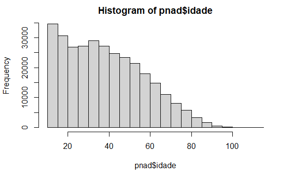

```r
hist(pnad$idade)
```

```r
pnad <- pnad %>%
  mutate(idadequadrado = idade*idade)
```

Agora fazendo a regressao:

```r
mq2 <- lm(salariom ~ sexo+educ+idade+cor+rural+idadequadrado, data = pnad, na.action=na.exclude)
summary(mq2)
```

```
Call:
lm(formula = salariom ~ sexo + educ + idade + cor + rural + idadequadrado,
    data = pnad, na.action = na.exclude)

Residuals:
   Min     1Q Median     3Q    Max
 -4466   -940   -312    379 196749

Coefficients:
                Estimate Std. Error t value Pr(>|t|)
(Intercept)   -1972.0934    50.9487  -38.71   <2e-16 ***
sexo           -812.3797    12.5962  -64.49   <2e-16 ***
educ            219.1662     1.6072  136.37   <2e-16 ***
idade            87.8082     2.3596   37.21   <2e-16 ***
cor             -71.8113     2.1902  -32.79   <2e-16 ***
rural          -312.2448    18.1008  -17.25   <2e-16 ***
idadequadrado    -0.5851     0.0280  -20.89   <2e-16 ***
---
Signif. codes:  0 ‘***’ 0.001 ‘**’ 0.01 ‘*’ 0.05 ‘.’ 0.1 ‘ ’ 1

Residual standard error: 2480 on 162568 degrees of freedom
  (146024 observations deleted due to missingness)
Multiple R-squared:  0.1643,    Adjusted R-squared:  0.1642
F-statistic:  5325 on 6 and 162568 DF,  p-value: < 2.2e-16
```

**R:** As informacoes no geral se mantiveram, no entanto, se nota uma diferenca do coeficiente para variável `idade` e da variavel `idadequadrado`, em que o primeiro está positivo e o segundo negativo, logo no primeiro a cada ano de idade, um aumento de 87 reais, enquanto no segundo a cada ano adicional de idade, deve-se aplicar o efeito na formula

Já que: “A interpretação da estimativa do estimador de 𝑥1 vai depender do seu valor”

(Comentário: modelo quadrático. Há valores ótimos existentes, o quadratico vai gerar um gráfico de curva com ponto ótimo, derivada igual a zero encontra o ponto ótimo. A interpretacao muda: o efeito é um aumento ou diminuicao de b1+b2+2b2x)

#### *PERGUNTA 4*

_A vice-diretora do projeto sugere que seria interessante estimar usar a transformação logarítmica na variável dependente, e pede para estimar uma *regressão do logaritmo natural do salário mensal no sexo e no número de horas de afazeres domésticos não remunerado (variável horasdom)*, *além das outras variáveis da questão anterior. O grupo tenta rodar uma nova regressão usando o logaritmo natural do salário mensal como variável dependente e sexo e horas de afazeres domésticos não remunerado como variáveis explicativas, incluindo as variáveis de controle da questão anterior, mas obtém o erro.*

*O erro quer dizer que a transformação logarítmica produziu o valor -∞ para indivíduos sem salário mensal (𝑠𝑎𝑙á𝑟𝑖𝑜𝑚 = 0), pois o logaritmo natural de 0 não é determinado. O grupo conversa com uma aluna terminando sua dissertação e ela sugere rodar o código abaixo para transformar os valores -∞ em dados faltantes (NA), onde pnad é o nome do objeto que armazena a base de dados.* *O grupo corrige o problema e roda novamente a regressão linear do logaritmo natural do salário mensal no sexo, nas horas de trabalho doméstico não remunerado e nas outras variáveis de controle da questão anterior. Funcionou!!! Agora sim, O grupo interpreta os coeficientes das horas de afazeres doméstico não remunerado, escolaridade e sexo*

```r
pnad <- pnad %>%
  mutate(logsalariom = log(salariom))

is.na(pnad) <- sapply(pnad, is.infinite) # transformando todos os - Inf # em missing data (NA)

#modelo log linear, em que a variável dependente y fica com log
lqo3 <- lm(logsalariom ~ sexo+educ+idade+cor+rural+idadequadrado+horasdom, data = pnad, na.action=na.exclude)
summary(lqo3)
```

```
Call:
lm(formula = logsalariom ~ sexo + educ + idade + cor + rural +
    idadequadrado + horasdom, data = pnad, na.action = na.exclude)

Residuals:
    Min      1Q  Median      3Q     Max
-5.5178 -0.3824  0.0157  0.4080  5.3312

Coefficients:
                Estimate Std. Error t value Pr(>|t|)
(Intercept)    5.002e+00  1.987e-02  251.71   <2e-16 ***
sexo          -3.497e-01  4.862e-03  -71.92   <2e-16 ***
educ           1.004e-01  5.721e-04  175.58   <2e-16 ***
idade          7.266e-02  9.417e-04   77.15   <2e-16 ***
cor           -3.542e-02  7.696e-04  -46.02   <2e-16 ***
rural         -3.675e-01  7.325e-03  -50.17   <2e-16 ***
idadequadrado -7.063e-04  1.124e-05  -62.85   <2e-16 ***
horasdom      -1.089e-02  2.101e-04  -51.82   <2e-16 ***
---
Signif. codes:  0 ‘***’ 0.001 ‘**’ 0.01 ‘*’ 0.05 ‘.’ 0.1 ‘ ’ 1

Residual standard error: 0.7004 on 105276 degrees of freedom
  (203315 observations deleted due to missingness)
Multiple R-squared:  0.3804,    Adjusted R-squared:  0.3804
F-statistic:  9234 on 7 and 105276 DF,  p-value: < 2.2e-16
```

A interpretacao muda, pois nao tenho mais y, tenho `log(y)`, assim um aumento de uma unidade de `x` nao leva a um aumento esperado de b1 em y. Aumentar 1 unidade `X` leva um aumento *relativo* de `b1*100%` em y

#### *PERGUNTA 5*

*Um aluno ingressante do mestrado acadêmico pergunta sobre a(s) razão(ões) pela qual fazemos a transformação logarítmica em uma variável dependente, e o grupo explica o(s) principais motivo(s)*

Motivos para usar o log:

1. Quando a relacao entre x e y é exponencial e nao linear
2. Quando o resíduo nao possui distribuicao normal

Sendo assim, respectivamente: 1. lineariza as relacoes, reduz a complexidade das relacoes matemáticas. 2. O log de y, leva a um um padrao esperado de uma distribuicao normal, pois simetriza e concentra valores, entao tende tornar uma coisa assimétrica para simétrica e trazer valores distantes para mais perto.

#### *PEGUNTA 6*

*Por fim, a vice-diretora comenta que a transformação logarítmica nas horas de afazeres domésticos também poderia ser feita, pois poderia facilitar a interpretação. O grupo faz a transformação e estima o modelo da questão 4. O grupo interpreta os coeficientes do log(ℎ𝑜𝑟𝑎𝑠𝑑𝑜𝑚) e escolaridade*

```r
pnad <- pnad %>%
  mutate(loghorasdom = log(horasdom))

lqo4 <- lm(logsalariom ~ sexo+educ+idade+cor+rural+idadequadrado+loghorasdom, data = pnad, na.action=na.exclude)
summary(lqo4)
```

```
Call:
lm(formula = logsalariom ~ sexo + educ + idade + cor + rural +
    idadequadrado + loghorasdom, data = pnad, na.action = na.exclude)

Residuals:
    Min      1Q  Median      3Q     Max
-5.5330 -0.3786  0.0185  0.4105  5.3632

Coefficients:
                Estimate Std. Error t value Pr(>|t|)
(Intercept)    5.163e+00  2.035e-02  253.65   <2e-16 ***
sexo          -3.583e-01  4.936e-03  -72.60   <2e-16 ***
educ           1.009e-01  5.737e-04  175.89   <2e-16 ***
idade          7.242e-02  9.455e-04   76.60   <2e-16 ***
cor           -3.543e-02  7.721e-04  -45.88   <2e-16 ***
rural         -3.677e-01  7.349e-03  -50.04   <2e-16 ***
idadequadrado -7.047e-04  1.128e-05  -62.48   <2e-16 ***
loghorasdom   -1.318e-01  2.948e-03  -44.71   <2e-16 ***
---
Signif. codes:  0 ‘***’ 0.001 ‘**’ 0.01 ‘*’ 0.05 ‘.’ 0.1 ‘ ’ 1

Residual standard error: 0.7027 on 105276 degrees of freedom
  (203315 observations deleted due to missingness)
Multiple R-squared:  0.3764,    Adjusted R-squared:  0.3764
F-statistic:  9080 on 7 and 105276 DF,  p-value: < 2.2e-16
```

(Comentários: Em caso de modelo linear log, onde y se mantém e o log ocorre nas variáveis independentes Interpretacao aproximada/relativa. aumentar 1% induz um aumento ou diminuicao de b1/100 unidades em y)

##### Duvidas gerais para aula

- Como analisar o resultado quando há todas as formas combinadas (log-linear, linear-log, quadrático)?
- Como avaliamos a relacao entre as variáveis independentes? Isso importa para análise?
- Qual o momento que retiramos uma variável ou quando percebemos que ela nao é relevante para o modelo?
- Como analisar o coeficiente quadrático? Realmente a A interpretação da estimativa do estimador de 𝑥1 vai depender do seu valor?
- Como interpretar o coeficiente de variáveis categoricas como cor?